# Análise de Resíduos

Primo iremos criar variaveis a partir de uma distrivuição uniforme, para a veriavel x. e para nossa variavel Y iremos criar a partir de uma distribuição de Poisson.

```r
x <- runif(200,0.5) #200 valores da uniforme 0.5
y <- rpois(200, lambda = exp((x)))

#tambem vamos sinular 200 valores para nossa resposta e iremos escrever a media , que é o lambda dessa maneira.
```

vamos fazer um grafico para entender o comportamento do X e Y

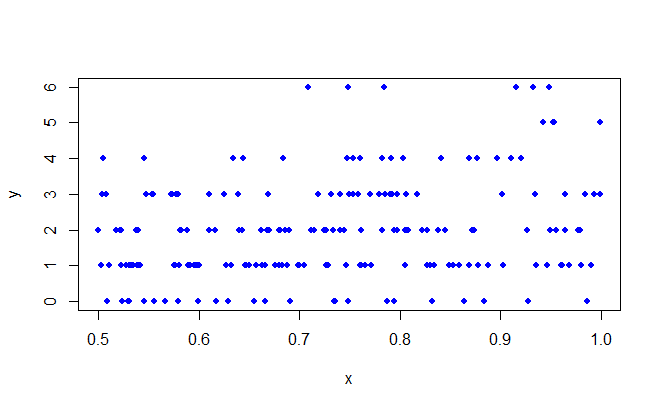

```r
plot(y ~ x, pch = 20 , cex =1.25, col = 'blue')
```

Priemiro vamos tentar ajustar um modelo com reposta normal

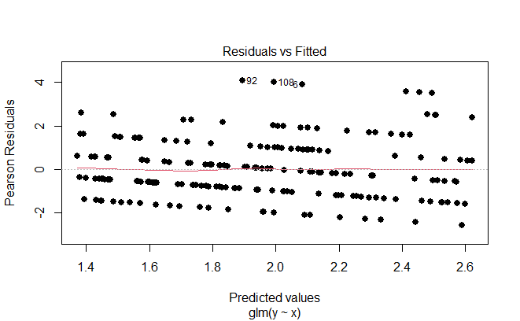

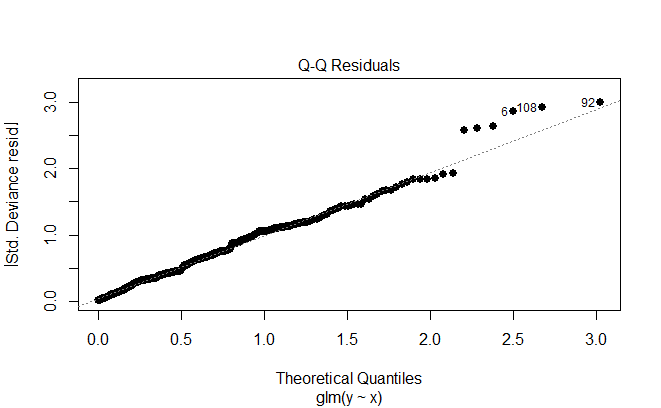

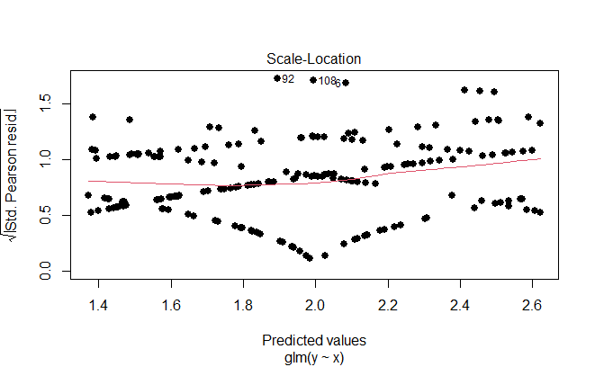

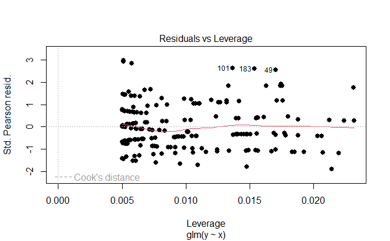

```r
glm_norm <- glm(y ~ x, family = gaussian)
par(mfrow = c(1,1))
plot(glm_norm, pch = 19 , cex = 1.1)
```

Teste de nomalidade dos residuos

```r
shapiro.test(glm_norm$residuals)
```

```
    Shapiro-Wilk normality test

data:  glm_norm$residuals
W = 0.96594, p-value = 9.204e-05
```

No plot temos 4 graficos, o grafico de residuos vs valores ajustados o qq-plot , os residuos studentizados , que é a raiz quadrada dos residuos e ainda temos o grafico de influencia , que analisa os residuos pela distancia de cook

```r
residuos <- qresid(glm_norm) #residuos quantilicos
ajustados <- predict(glm_norm) #valores ajustados
```

Quando o modelo esta correto , o residuo quantilico deve acusar que tem distribuição normal

```r
shapiro.test(residuos)
```

```
    Shapiro-Wilk normality test

data:  residuos
W = 0.96594, p-value = 9.204e-05
```

Logo o modelo não esta bem ajustado

Podemos realizar um Grafico de residuos versusu valores ajustados e qqpolt

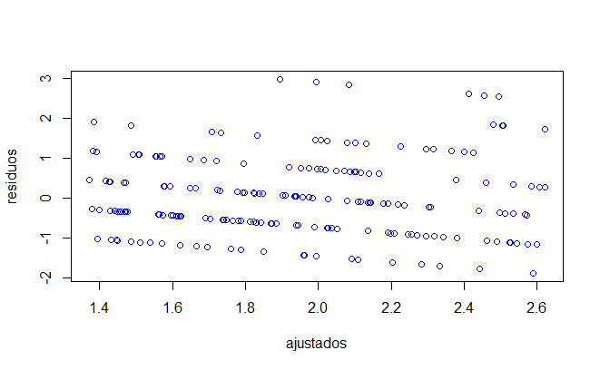

```r
par(mfrow = c(1,1))
plot(residuos ~ ajustados, col = 'blue')
```

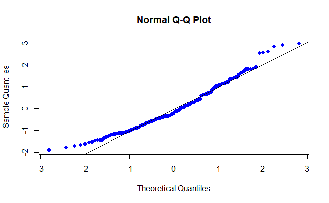

```r
qqnorm(residuos, pch = 20 , cex =1.4, col = 'blue')
qqline(residuos)
```

Entao como estamos trabalhando com contagens vamos utilizar um GLM de poisson

```r
glm_poisson <- glm(y ~ x, family = poisson)
```

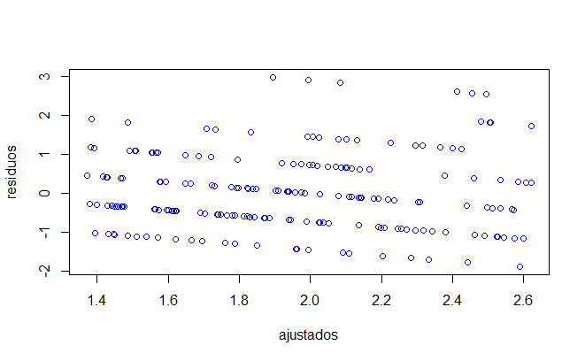

```r
par(mfrow = c(1,1))
plot(residuos ~ ajustados, col = 'blue')
```

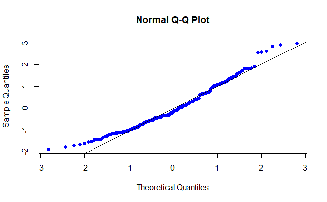

```r
qqnorm(residuos, pch = 20 , cex =1.4, col = 'blue')
qqline(residuos)
```

```r
residuos <- qresid(glm_poisson) #residuos quantilicos
ajustados <- predict(glm_poisson) #valores ajustados

shapiro.test(residuos)
```

```
    Shapiro-Wilk normality test

data:  residuos
W = 0.99367, p-value = 0.5526
```

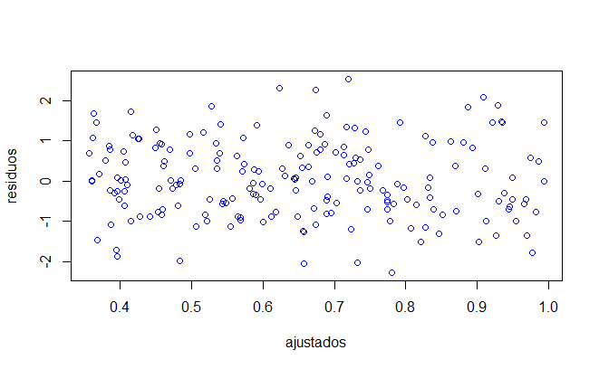

```r
par(mfrow = c(1,1))
plot(residuos ~ ajustados, col = 'blue')
```

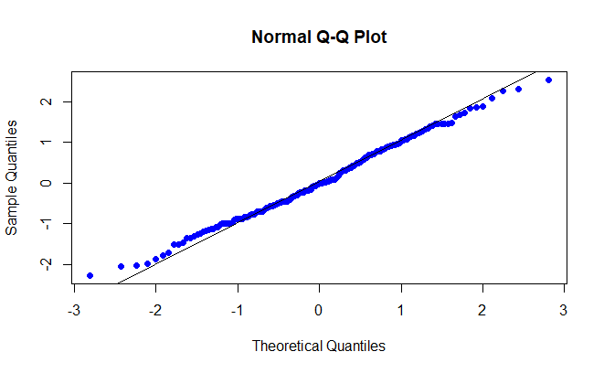

```r
qqnorm(residuos, pch = 20 , cex =1.4, col = 'blue')
qqline(residuos)
```

Exemplo - Regressão Binomial

Considerando uma binomial.

Primero iremos criar as variáveis

```r
x <- c(3.4,5.5,6.2,4.5,6.5,6.8,5.2,4.9,5.9,4.6,
       6.2,3.3,6.4,5.3,5.1,5.6,3.8,5.3,5.1,5.8,
       4.5,4.2,5.8,3.6,4.2,6.0,7.1,4.9,4.8,4.0,
       6.3,6.9,5.6,6.0,4.1,3.9,6.2,3.5,5.1,2.5,
       5.2,5.3,3.1,3.6,5.8,5.4,5.1,3.8,6.1,4.9)
y <- c(1,1,0,0,0,0,0,0,1,0,
       0,0,1,0,0,0,0,0,0,0,
       0,0,0,0,1,1,1,0,0,0,
       1,1,0,1,0,0,0,0,0,0,
       0,1,0,1,0,1,0,0,1,0)
```

Observe que o plot teria apenas valores de 0 e 1

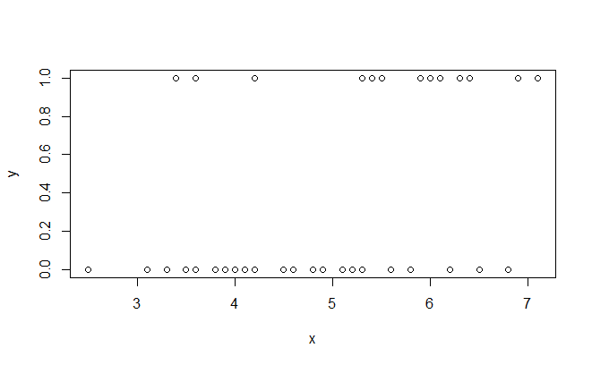

```r
par(mfrow = c(1,1))
plot(x,y)
```

Configurando o modelo binomial

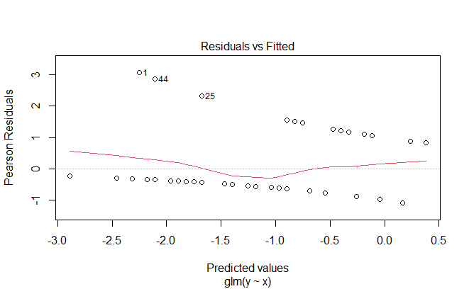

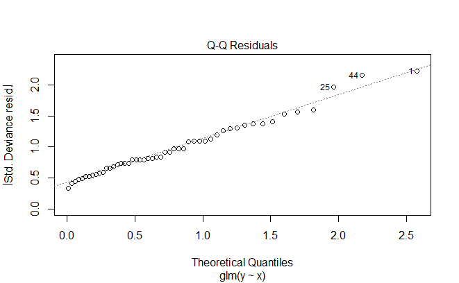

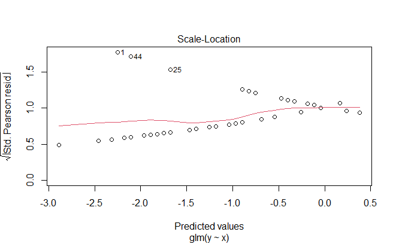

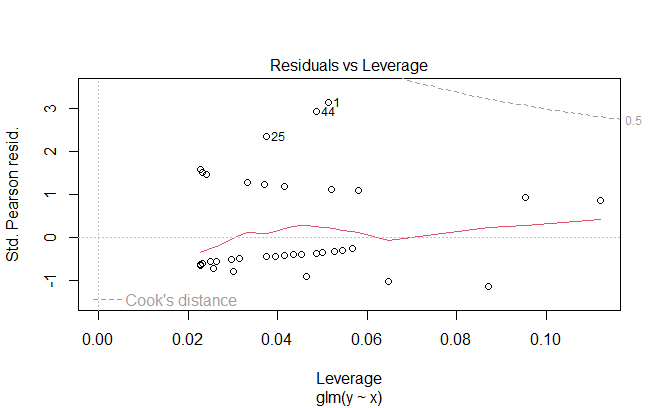

```r
glm_log <- glm(y ~ x , family = binomial)
plot(glm_log)
```

Verificando a normalidade. Obs. nesse caso nao podemos querer a normalidade pois nao temos residuos quantilicos

```r
shapiro.test(glm_log$residuals)
```

```
    Shapiro-Wilk normality test

data:  glm_log$residuals
W = 0.66611, p-value = 2.141e-09
```

analisando via residuos quantilicos

```r
residuos <- qresid(glm_log) #residuos quantilicos
ajustados <- predict(glm_log) #valores ajustados
shapiro.test(residuos)
```

```
    Shapiro-Wilk normality test

data:  residuos
W = 0.97544, p-value = 0.3793
```

```r
par(mfrow = c(1,2))
plot(residuos ~ ajustados, col = 'blue')
qqnorm(residuos, pch = 20 , cex =1.4, col = 'blue')
```

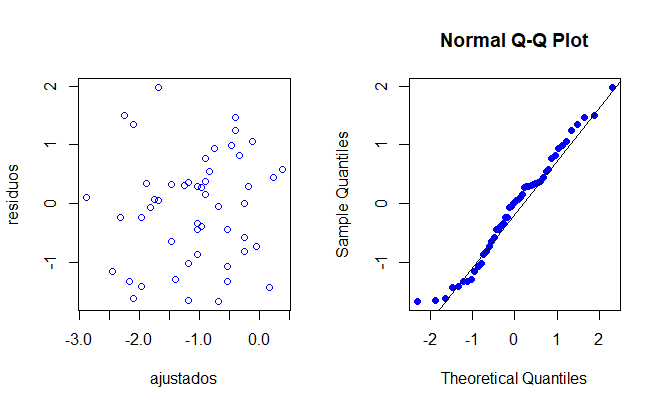

```r
qqline(residuos)
```